# DigitalTwinsTextClustering

```python
import sys
!{sys.executable} -m pip install numpy
```

```
  Using cached numpy-1.20.3-cp38-cp38-macosx_10_9_x86_64.whl (16.0 MB)
ERROR: tensorflow 2.4.1 has requirement numpy~=1.19.2, but you'll have numpy 1.20.3 which is incompatible.
ERROR: tensorflow-cpu 2.4.1 has requirement numpy~=1.19.2, but you'll have numpy 1.20.3 which is incompatible.
```

```python
import sys
!{sys.executable} -m pip install hdbscan --no-cache-dir --no-binary :all:
```

```
     |████████████████████████████████| 6.4 MB 5.6 MB/s eta 0:00:01
  Installing build dependencies ... done
  Getting requirements to build wheel ... done
    Preparing wheel metadata ... done
```

```python
import pandas as pd
import numpy as np
import matplotlib.pyplot as plt
import string
import re
from sklearn.feature_extraction.text import TfidfVectorizer
from sklearn.cluster import KMeans
import hdbscan
from sklearn import preprocessing
from sklearn.decomposition import TruncatedSVD
from wordcloud import WordCloud
import scipy
import nbconvert
```

```python
data = pd.read_csv("digital_twin_tweets_df.csv") #load data
```

```python
data.shape #check dimensions
```

```
(431406, 4)
```

```python
data.dtypes #check dtypes
```

```
author_id     int64
source       object
text         object
year          int64
dtype: object
```

We need to tokenise the text data so that we can use ML algorithms on it. Do do so we use the TfidfVectorizer from the scikit-learn package.

```python
tfidf_vectorizer = TfidfVectorizer()
tfidf = tfidf_vectorizer.fit_transform(data["text"].values.astype('U'))
```

# Clustering

## K-means

This produces a sparse matrix which we can use for clustering.

```python
# define arguments for k-means algorithm
kmeans_kwargs = {
    "init": "random",
    "n_init": 10,
    "max_iter": 300,
    "random_state": 42, # set random state for reproducability
}
```

K-means requires us to manually set the number of clusters. We will use the elbow rule to identify the optimal number of clusters. We run the algorithm for K equals to 1 or more until 10.

```python
# we create a list which holds sse for each clustering iteration
sse = []
for k in range(1, 11):
    #input the arguments defined in prev cell
    kmeans = KMeans(n_clusters=k, **kmeans_kwargs)
    kmeans.fit(tfidf)
    sse.append(kmeans.inertia_)
```

We plot the sse for all cluster algorithm runs.

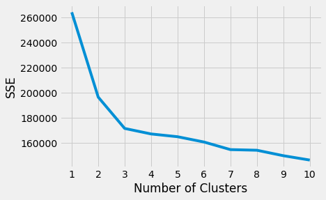

```python
plt.style.use("fivethirtyeight")
plt.plot(range(1, 11), sse)
plt.xticks(range(1, 11))
plt.xlabel("Number of Clusters")
plt.ylabel("SSE")
plt.show()
```

There is a evident pivot at k=3. This indicates that this is the optimal number of clusters.

```python
kmeans = KMeans(n_clusters=3, random_state=42).fit(tfidf) # final algortim run with k = 3
```

```python
data["cluster_labels"] = kmeans.labels_ #assign cluster labels to df
```

## HDBScan

As seen on the data preparation stage we are dealing with very sparse data. The current implementation of HDBScan is not able to handle such large dimensions. Therefore we return to the data preparation stage to reduce dimensionality of the data. The goal is to capture as much of the variance present whilst reducing the number of columns/features.

```python
# we use TruncatedSVD from sklearn which is designed to deal with sparse data.
tfidf_new = TruncatedSVD(40) # set target of 40 columns
```

```python
tsvd = tfidf_new #replace old matrix
# covert back into a sparse data type
X_sparse_tsvd = tsvd.fit(tfidf).transform(tfidf)
```

We need to check how much of the variance is captured in the new matrix. Idealy this is over 60%

```python
print("Original number of features:", tfidf.shape[1])
print("Reduced number of features:", X_sparse_tsvd.shape[1])
print(); print(tsvd.explained_variance_ratio_[0:40].sum())
```

```
Original number of features: 365
Reduced number of features: 40

0.7541797331247228
```

We have succeeded in capturing 75% of variance in 40 columns. Good resutls. To improve the algortihm further we can scale the results.

```python
scaler = preprocessing.StandardScaler().fit(X_sparse_tsvd) # scale data
```

```python
df_scaled = scaler.transform(X_sparse_tsvd)
```

### Iteration 1

```python
# configure algorithm
# most important arguments are min_cluster_size=5, min_samples=None
clusterer = hdbscan.HDBSCAN(algorithm='best', alpha=1.0, approx_min_span_tree=True,
    gen_min_span_tree=True, leaf_size=40,
    metric='euclidean', min_cluster_size=5, min_samples=None, p=None)
```

```python
cluster_labels = clusterer.fit_predict(df_scaled) #run algorithm
```

```python
len(np.unique(cluster_labels)) #check number of clasters
```

```
164
```

```python
data["cluster_labels_HDBSCAN"] = cluster_labels #assign cluster labels to df
```

### Iteration 2

```python
clusterer_2 = hdbscan.HDBSCAN(algorithm='best', alpha=1.0, approx_min_span_tree=True,
    gen_min_span_tree=True, leaf_size=40,
    metric='euclidean', min_cluster_size=50, min_samples=100, p=None)
```

```python
cluster_labels_2 = clusterer_2.fit_predict(df_scaled)
```

```python
len(np.unique(cluster_labels_2))
```

```
163
```

```python
data["cluster_labels_HDBSCAN_2"] = cluster_labels_2 #assign cluster labels to df
```

# Results

## Cluster Sizes

#### K-means

```python
data.head()
```

|  | author_id | source | text | year | cluster_labels |
| --- | --- | --- | --- | --- | --- |
| 0 | 5544032 | Twitter Web Client | bajaj new growth engine literally bajaj auto u... | 2007 | 0 |
| 1 | 5544032 | Twitter Web Client | bajaj autos dtssi engine offers kml bajaj thur... | 2007 | 0 |
| 2 | 17278675 | Twitter Web Client | bajaj new growth engine literally bajaj auto u... | 2008 | 0 |
| 3 | 13001192 | Twitter Web Client | bajaj autos dtssi engine offers kml bajaj thur... | 2008 | 0 |
| 4 | 14263808 | Twitter Web Client | twin cities tv viewers get ready digital twin ... | 2008 | 0 |

First we want to check the size of the clusters

```python
k_clusters = data.groupby("cluster_labels")
```

```python
k_clusters.count().head()
```

| cluster_labels | author_id | source | text | year | cluster_labels_HDBSCAN |
| --- | --- | --- | --- | --- | --- |
| 0 | 42156 | 42156 | 42156 | 42156 | 42156 |
| 1 | 209937 | 209937 | 209937 | 209937 | 209937 |
| 2 | 179313 | 179313 | 177551 | 179313 | 179313 |

Cluster 1 and 2 are of similar size whilst cluster 0 is smaller. Generally we aim for balanced clusters. This is not a bad but not a perfect result.

#### HDBScan: Iteration 1

```python
HDBSCAN_clusters = data.groupby("cluster_labels_HDBSCAN")
```

```python
HDBSCAN_clusters.size().sort_values(ascending=False)
```

```
cluster_labels_HDBSCAN
155    208211
116     16961
133      9983
130      8901
78       8417
        ...
131       420
162       225
151       109
114        62
148        37
Length: 164, dtype: int64
```

We have one large cluster and all other are comparatively small. This indicates a lack of structure in the data. To understand the clusters of each algorithm better we will produce wordclounds for all clusters in K-means and the top 5 of HDBScan.

#### HDBScan: Iteration 2

```python
HDBSCAN_clusters_2 = data.groupby("cluster_labels_HDBSCAN_2")
```

```python
HDBSCAN_clusters_2.size().sort_values(ascending=False)
```

```
cluster_labels_HDBSCAN_2
 153    208211
 116     16961
 132      9983
 129      8901
 86       8417
         ...
 94        573
 130       420
 157       225
 149       109
-1          37
Length: 163, dtype: int64
```

The second iteration with higher min_cluster_size and min_samples produces the same clusters towards the top. This suggests that they are stable. We will omit this iteration when looking at cluster composition as it is identical to iteration 1.

## Cluster Composition

### HBDScan

```
Cluster: 155
```

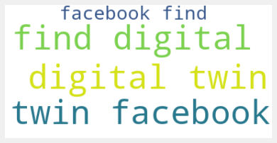

```
Cluster: 116
```

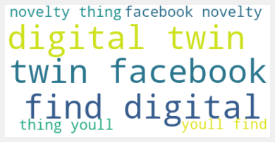

```
Cluster: 133
```

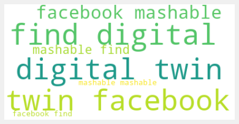

```
Cluster: 130
```

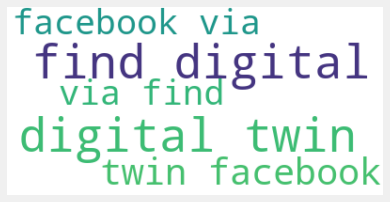

```
Cluster: 78
```

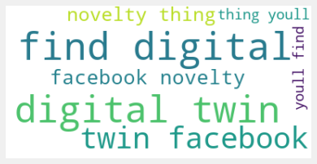

```python
HDBSCAN_clusters_vis = HDBSCAN_clusters.size().sort_values(ascending=False)[:5] #grab the top sized clusters
for cluster in HDBSCAN_clusters_vis.index:
    print(f"Cluster: {cluster}")
    wordcloud = WordCloud(max_font_size=50, max_words=100, background_color="white").generate(data["text"][data["cluster_labels_HDBSCAN"] == cluster].to_string())
    #plot configuration
    plt.figure()
    plt.imshow(wordcloud, interpolation="bilinear")
    plt.axis("off")
    plt.savefig(f"HBDScan_Cluster_{cluster}.png")
    plt.show()
```

For ease of interpretation we can also do a more basic visualisation.

```python
for cluster in HDBSCAN_clusters_vis.index:
    print(f"Cluster: {cluster}")
    string = data["text"][data["cluster_labels_HDBSCAN"] == cluster][0:5].to_string()
    print(string)
```

[output not shown]

```python
HDBSCAN_clusters = data.groupby(cluster_labels_2)
HDBSCAN_clusters_vis = HDBSCAN_clusters.size().sort_values(ascending=False)[:5]
```

```python
HDBSCAN_clusters_vis
```

```
153    208211
116     16961
132      9983
129      8901
86       8417
dtype: int64
```

```python
for cluster in HDBSCAN_clusters_vis.index:
    print(f"Cluster: {cluster}")
    string = data["text"][data["cluster_labels_HDBSCAN_2"] == cluster][0:5].to_string()
    print(string)
```

```
Cluster: 153
16    find digital twin facebook
17    find digital twin facebook
21    find digital twin facebook
24    find digital twin facebook
35    find digital twin facebook
Cluster: 116
36     find digital twin facebook novelty thing youll...
181    find digital twin facebook novelty thing youll...
276    find digital twin facebook novelty thing youll...
297    find digital twin facebook novelty thing youll...
348    find digital twin facebook novelty thing youll...
Cluster: 132
18     find digital twin facebook mashable
20     find digital twin facebook mashable
59     mashable find digital twin facebook
107    mashable find digital twin facebook
135    mashable find digital twin facebook
Cluster: 129
73     find digital twin facebook via
154    find digital twin facebook via
218    find digital twin facebook via
228    find digital twin facebook via
269    find digital twin facebook via
Cluster: 86
312    find digital twin facebook novelty thing youll...
313    find digital twin facebook novelty thing youll...
314    find digital twin facebook novelty thing youll...
342    find digital twin facebook novelty thing youll...
391    find digital twin facebook novelty thing youll...
```

### K-means

```
Cluster: 0
```

[figure not shown]

```
Cluster: 1
```

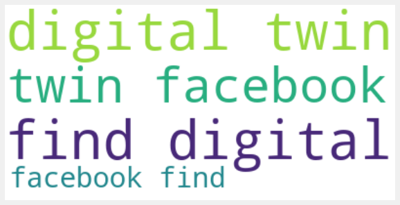

```
Cluster: 2
```

[figure not shown]

```python
for cluster in k_clusters.size().index:
    print(f"Cluster: {cluster}")
    string = data["text"][data["cluster_labels"] == cluster][0:15].to_string()
    wordcloud = WordCloud(max_font_size=70, max_words=100, background_color="white").generate(string)
    plt.figure(figsize=(9, 9))
    plt.imshow(wordcloud, interpolation="bilinear")
    plt.axis("off")
    plt.savefig(f"Kmeans_Cluster_{cluster}.png")
    plt.show()
```

```python
for cluster in k_clusters.size().sort_values(ascending=False).index:
    print(f"Cluster: {cluster}")
    string = data["text"][data["cluster_labels"] == cluster][0:10].to_string()
    print(string)
```

[output not shown]

[output cut: 18 more lines]

## Discussion

The chief difference between the two algorithms is that K-means groups together all the remaining terms into cluster 0 whilst HDBScan seemingly overfits and tries to create more clusters based on individual word variations. We have attempted to address this issue and discover better structures by running HDBScan a second time with higher values for different parameters. However, the results remain the same which is evidence of cluster stability. In the end the K-means results generalise better.